# 공공 AI의 역설

무료 배포는 왜 중산층을 구하지 못하는가 — 경제학 × 정치철학 × 교육학 × 디지털 공공재

저자

Nakcho Choi · Insight Lab

공개

2026년 8월 9일

▶

**AI 오디오 리뷰**

[1 · AI 무료 배포가 중산층을 붕괴시키는 이유 ↗](https://notebook.google.com/notebook/2981c6a3-ac3b-45ee-8342-dd3e7c6b8d0b/artifact/cd775ec8-8ace-4bd4-842c-46a8faecf455?utm_source=nlm_web_share&utm_medium=google_oo&utm_campaign=art_share_1)

[2 · AI 양극화 89%를 막는 4단계 해법 ↗](https://notebook.google.com/notebook/2981c6a3-ac3b-45ee-8342-dd3e7c6b8d0b/artifact/f342da63-5c93-4f08-8f32-68b3e16f7901?utm_source=nlm_web_share&utm_medium=google_oo&utm_campaign=art_share_1)

NotebookLM 공개 오디오 · 새 창에서 재생

**자료 성격 고지.** 아래 수치는 한국 사회의 예측값이나 실제 정책효과 추정치가 아니다. 서로 다른 제도 설계가 어떤 경로로 양극화를 키우거나 줄이는지 비교한 **이론 기반 합성 모의실험**이다. 실험 코드·원자료·영문 경제학 논문은 [공개 저장소](https://github.com/waterfirst/public-ai-inequality-economics)에서 재현할 수 있다.

# 1 무료 AI라는 직관

공공 와이파이는 연결 비용을 낮췄다. 공교육은 부모의 소득과 무관하게 최소한의 학습 기회를 보장하려 했다. 그렇다면 AI 시대의 다음 사회 인프라는 **전 국민 AI 이용권**이어야 하지 않을까? 복지 신청을 돕고, 공무원이 취약계층을 더 빨리 발견하고, 누구나 개인 교사와 법률·세무 길잡이를 갖게 하는 공공 또는 소버린 AI 말이다.

이 직관은 옳다. 그러나 절반만 옳다.

2025년 OECD 회원국의 생성형 AI 이용률 격차는 연령 집단 사이에서 **53.6%포인트**, 학력과 소득 집단 사이에서 각각 약 **21%포인트**였다. 접속 격차부터 이미 크다. 하지만 계정만 나눠 준 뒤에는 더 어려운 두 번째 격차가 나타난다. 같은 AI를 받아도 누군가는 질문을 만들고, 데이터를 연결하고, 결과를 검증해 사업과 자산으로 바꾼다. 다른 누군가는 한 번 검색하고 떠난다. [OECD의 2026년 AI 이용 현황](https://www.oecd.org/en/about/news/announcements/2026/01/ai-use-by-individuals-surges-across-the-oecd-as-adoption-by-firms-continues-to-expand.html)

**이 글의 중심 명제**  
AI는 독립적인 생산요소라기보다 기술·데이터·직업 유연성·자본과 결합할 때 가치가 커지는 **보완재의 증폭기**다. 따라서 동일한 접속권은 동일한 경제적 능력이 아니다.

# 2 접속이 아니라 ‘유효 AI’가 문제다

한 개인이 실제로 사용할 수 있는 AI 서비스 (E_i)를 다음처럼 생각해 보자.

$$E_i=A_i\times Q_i\times T_i\times H_i\times F_i$$

- (A_i): 접속 가능성
- (Q_i): 모델 품질과 사용량
- (T_i): 신뢰와 안전성
- (H_i): AI를 다룰 기술·도메인 지식
- (F_i): 직업과 조직이 AI를 받아들일 유연성

곱셈 구조의 의미는 잔인하다. 공공 AI가 (A_i)를 1에 가깝게 올려도, 나머지 한 항이 0에 가까우면 유효 능력은 작다. 반대로 고소득층은 고가 모델, 더 긴 추론 예산, 사유 데이터, 전문가 네트워크와 자본을 동시에 결합한다. 격차는 ‘무료 사용자 대 유료 사용자’에서 끝나지 않고 **AI를 자산으로 전환하는 사람과 소비로 끝내는 사람** 사이로 이동한다.

아마르티아 센의 역량 접근은 이 문제를 오래전에 예고했다. 같은 자원을 배분해도 개인이 그것을 실질적 자유로 전환하는 능력은 다르다. 공공 AI의 목표가 공정한 기회라면, 보급률이 아니라 **누가 더 나은 선택과 소득·시간·권리를 얻었는가**를 측정해야 한다.

# 3 4,728개의 가상 사회

이를 확인하기 위해 서로 다른 소득·기술·직업 노출·적응력·돌봄 부담·AI 자본 소유를 가진 합성 가구를 만들고, 15기간 동안 여섯 제도를 비교했다.

1. 시장과 고가 AI 중심
2. 전 국민 공공 AI
3. 공공 AI와 공교육
4. 공공 AI와 돌봄 서비스
5. 교육·돌봄·AI 자본배당·노동자 소유를 결합한 종합안
6. 품질과 신뢰가 낮은 명목상 공공 AI

기준·임계조건 실험 **1,128회**, 기술과 비용 변수를 바꾼 몬테카를로 실험 **3,600회**를 합쳐 총 **4,728회**다. 양극화는 단순한 소득격차와 구분하기 위해 Wolfson 지수를 사용했다. 이 지수는 분포가 중위소득 주변에서 두 극단으로 갈라지는 현상, 즉 **중산층 공동화**에 민감하다.

## 3.1 무료 접속은 증가폭만 낮췄다

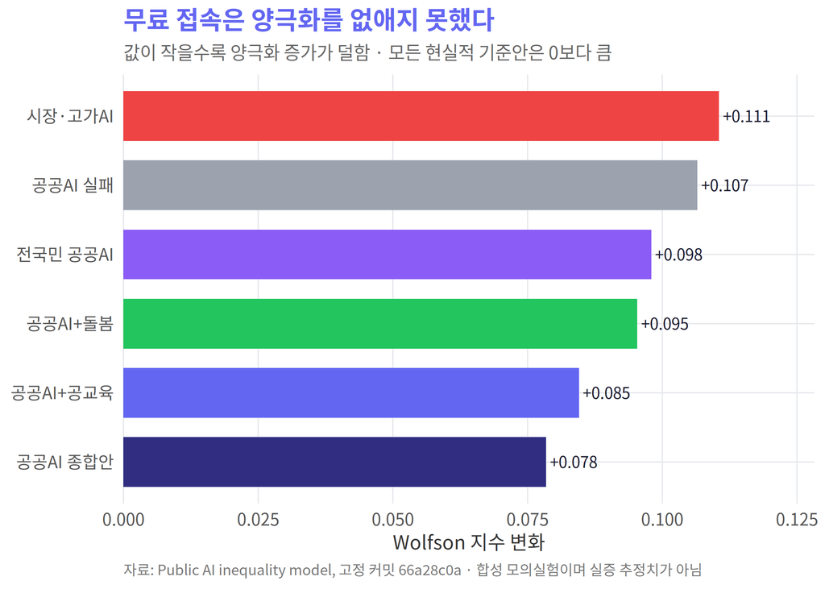

그림 1: 그림 1. 기준 모의실험의 Wolfson 양극화 증가폭. 공공 AI는 증가를 늦추지만 현실적 기준 조건에서는 되돌리지 못한다.

시장·고가 AI 조건에서 Wolfson 지수는 **0.1105** 증가했다. 전 국민 공공 AI는 증가폭을 **11.4%** 줄였지만 양극화 방향 자체는 바꾸지 못했다. 공공교육 결합은 **23.5%**, 종합안은 **29.0%** 낮췄다. 품질·신뢰가 낮은 공공 AI는 겨우 **3.6%** 줄였다. ‘무료’라는 가격표보다 **무엇을 할 수 있는 품질인가**가 중요하다는 뜻이다.

## 3.2 성장과 분배는 같은 축이 아니다

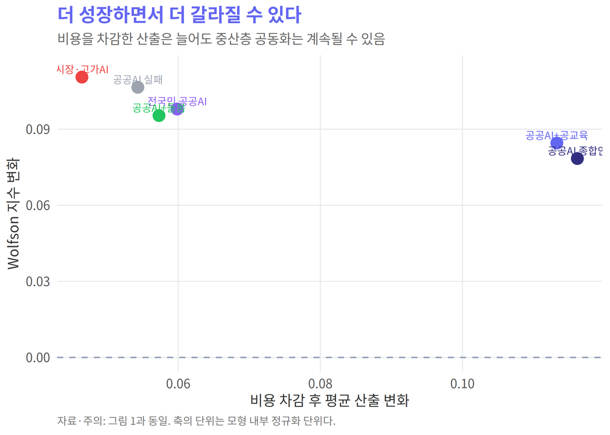

그림 2: 그림 2. 비용 차감 후 산출 증가와 양극화 증가의 관계. 오른쪽 아래가 더 유리하지만 어떤 정책도 기준 조건에서 양극화를 역전하지 못한다.

가장 중요한 결과는 성장과 복지가 갈라졌다는 점이다. 시장 조건에서도 평균 산출은 늘었지만 불평등을 반영한 동등분배소득(EDE)은 감소했다. 종합안만 기준 비용에서 순 EDE가 소폭 플러스였다. **GDP가 늘었다는 사실은 중간층이 살아남았다는 증거가 아니다.**

# 4 왜 공교육이 접속권보다 강했나

공공교육은 AI 계정을 더 배포하지 않는다. 대신 (H_i), 즉 결과를 검증하고 작업 흐름에 연결하는 능력을 바꾼다. 그래서 기준 실험에서 공공 AI+교육은 단순 보급보다 양극화 억제와 순산출 모두에서 앞섰다.

이 결과는 교육을 ‘프롬프트 요령’으로 축소하라는 뜻이 아니다. OECD는 범용 생성형 AI가 과제 성과를 높여도 교육적 설계가 없으면 실제 학습으로 이어지지 않을 수 있다고 경고한다. 필요한 것은 답을 대신 쓰는 기술이 아니라 다음의 순환이다. [OECD Digital Education Outlook 2026](https://www.oecd.org/en/publications/oecd-digital-education-outlook-2026_062a7394-en.html)

> 문제를 정의한다 → 자료의 출처를 묻는다 → AI가 만든 가설을 반증한다 → 도메인 지식으로 오류를 찾는다 → 결과와 책임을 사람이 승인한다.

그러나 공교육과 공공 AI 사이에는 결정적 차이가 있다. 교과서는 개정 주기가 길지만 AI 모델은 수개월마다 능력과 위험이 바뀐다. 국가는 하나의 ‘정답 모델’을 지정할 수 없고, 정권이 바뀔 때마다 가치와 금지어가 바뀌어서도 안 된다. 따라서 공공 AI는 국영 챗봇 하나가 아니라 **법으로 보장된 최소 이용권과 복수 운영자 구조**여야 한다.

# 5 돌봄 AI: 작은 평균, 큰 삶

돌봄 정책은 전체 평균에서는 교육보다 작았다. 하지만 취약집단 고용에는 달랐다. 기준 실험에서 공공교육 결합은 취약집단 고용을 **2.05%포인트**, 돌봄 결합은 **2.46%포인트**, 종합안은 **5.49%포인트** 높였다.

돌봄 AI의 가치는 거창한 생산성보다 행정 마찰을 줄이는 데 있다. 복지 자격을 찾고, 제출 서류를 설명하고, 예약과 이동을 조정하고, 담당 공무원에게 위험 신호를 보여주는 일이다. 단, 의료·법률·세무 판단과 급여 거절은 사람이 책임져야 한다. 자동화된 편의가 자동화된 배제가 되지 않도록 **인간 이관과 이의신청권**이 제도 안에 있어야 한다.

# 6 200개의 미래에서도 살아남은 것

기술의 속도, 고가 모델의 우위, AI 자본수익, 누적 피드백, 공공서비스 비용을 바꾼 200개 환경에서 각 정책을 같은 조건으로 비교했다.

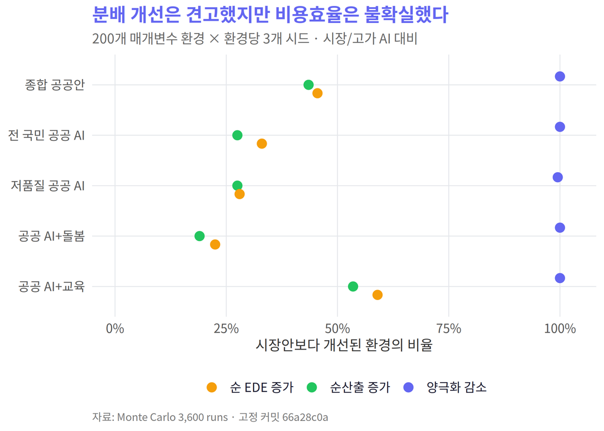

그림 3: 그림 3. 200개 불확실한 기술·비용 환경에서 시장안보다 나아질 확률. 양극화 감소와 순효율 개선은 서로 다른 판정이다.

모든 실질적 공공안은 표본화한 환경 전부에서 시장안보다 양극화를 낮췄다. 그러나 비용까지 빼면 순산출을 함께 높인 비율은 교육 결합 **53.5%**, 종합안 **43.5%**, 단순 보급 **27.5%**, 돌봄 **19.0%**였다. 분배상 유리한 정책이 항상 비용효율에서도 우월하지는 않다.

여기서 ‘교육이 무조건 정답’이라는 결론을 내리면 안 된다. 이 순위는 모형 구조와 비용 범위 안에서 나온다. 돌봄은 작은 집단을 깊게 돕기 때문에 총산출 지표에서 불리할 수 있다. 공공서비스의 가치를 평균 생산성 하나로만 평가하면, 원래 보호하려던 사람을 다시 지표 밖으로 밀어낸다.

# 7 경계면: 언제 공공 AI도 무너지는가

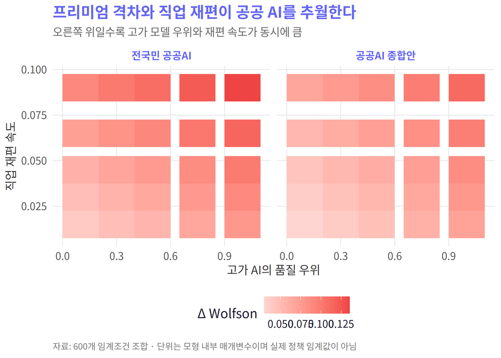

그림 4: 그림 4. 고가 모델의 품질 우위와 직업 재편 속도가 커질수록 공공 AI 아래에서도 양극화가 확대된다.

공공 AI의 적은 단순히 예산 부족이 아니다. **프리미엄 능력의 발전 속도**와 **직업이 재편되는 속도**가 교육과 제도 적응보다 빠르면, 공공서비스는 늘 한 세대 뒤처진다. 저소득층에게 어제의 모델을 무료로 주고 부유층이 내일의 모델을 사는 체계는 디지털 복지가 아니라 지연된 계층화다.

# 8 반대도 깊은 진리다

Insight Lab의 질문은 늘 반대편까지 가야 완성된다. AI가 반드시 양극화를 만든다는 명제는 사실이 아니다.

미국 고객지원 현장실험에서는 생성형 AI가 평균 생산성을 높였고, 특히 경험이 적은 노동자의 향상이 더 컸다. 숙련자의 암묵지를 시스템이 전달했기 때문이다. AI는 격차의 증폭기인 동시에 **숙련 확산기**가 될 수 있다. [Brynjolfsson·Li·Raymond, *Generative AI at Work*](https://www.nber.org/papers/w31161)

그래서 강한 가설—‘AI는 언제나 양극화를 만든다’—은 기각되어야 한다. 더 정확한 조건부 명제는 다음과 같다.

AI가 기존 자원과 결합해 차등 수익을 만들고, 비적응 노동에 대체 손실을 주며, 그 이득이 기술·데이터·자본으로 재투자될 때 양극화는 누적된다. 반대로 AI가 낮은 초기 역량에 더 큰 한계생산성 향상을 주고, 재교육과 직업 이동이 재편 속도를 따라가며, AI 자본수익이 넓게 소유되면 격차는 줄어들 수 있다.

# 9 공공 AI 헌법은 무엇이어야 하나

공교육 논쟁은 정권이 바뀔 때마다 반복된다. 자유와 평등, 선택과 표준화, 국가 책임과 사적 혁신이 충돌하기 때문이다. AI 이용권도 같은 논쟁을 피할 수 없다. 오히려 AI는 사용자의 질문·기록·취약성을 축적하고 실시간으로 답을 생성하기 때문에 더 민감하다.

정권과 기술 유행을 넘어 유지될 원칙은 서비스 이름이 아니라 **권리 구조**여야 한다.

1. **최소 AI 이용권** — 일정 수준 이상의 품질·사용량·접근성을 법적 권리로 보장한다.
2. **복수 모델 선택권** — 단일 국영 모델이 아니라 인증된 공공·민간·오픈·온디바이스 모델 사이 이동을 허용한다.
3. **데이터 이동성과 최소수집** — 시민이 대화와 작업 기록을 이전·삭제할 수 있어야 한다.
4. **검증 가능한 공교육** — 질문법보다 출처 확인, 반증, 도메인 검토, 책임 있는 승인에 투자한다.
5. **인간에게 이의제기할 권리** — 복지·채용·의료·법률·세무의 고위험 결정에는 설명과 사람의 재심을 보장한다.
6. **AI 자본의 분산 소유** — 노동자 지분, 연기금, 지역펀드, 공공 배당으로 임금 밖의 자본수익 경로를 넓힌다.
7. **독립 감사와 공개 평가** — 정권·조달업체와 분리된 기관이 편향·비용·오류·집단별 성과를 공개한다.

세계은행은 디지털 공공 인프라의 핵심을 단일 앱이 아니라 신원·지급·데이터 교환 같은 재사용 가능한 공공 기반으로 본다. 공공 AI도 ‘정부가 만든 챗봇’보다 **시민이 여러 서비스에서 행사할 수 있는 상호운용 권리**에 가까워야 한다. [World Bank의 Digital Public Infrastructure](https://www.worldbank.org/en/results/2026/05/06/global-digital-public-infrastructure-program)

# 10 결론: 배포가 아니라 전환 능력

AI 시대의 평등은 모두에게 같은 답변창을 주는 일이 아니다. 누군가는 AI로 회사를 만들고 자본을 축적하는데, 누군가는 복지 신청 한 건을 마치는 데 그친다면 접속은 평등해도 결과를 만드는 자유는 평등하지 않다.

모의실험의 가장 일관된 메시지는 단순하다.

> **공공 AI는 필요조건이지만 충분조건이 아니다.**  
> 접속권에 교육·돌봄·직업 이동·자본 소유를 결합해야 한다.

공공 와이파이는 길을 열었다. 공교육은 읽고 판단하는 능력을 만들려 했다. 공공 AI는 그 둘 위에 서되, 한 단계 더 나아가야 한다. 시민에게 기계를 주는 것이 아니라 **기계가 바꾸는 사회에서 다시 선택할 능력**을 주어야 한다.

## 연구·재현 자료

- [영문 경제학 워킹페이퍼·코드·전체 결과](https://github.com/waterfirst/public-ai-inequality-economics)
- [영문 PDF 직접 보기](https://github.com/waterfirst/public-ai-inequality-economics/raw/main/Public_AI_Social_Infrastructure_Economics_Working_Paper_2026-08-09.pdf)
- [AI 오디오 해설 — AI 무료 배포가 중산층을 붕괴시키는 이유](https://notebook.google.com/notebook/2981c6a3-ac3b-45ee-8342-dd3e7c6b8d0b/artifact/cd775ec8-8ace-4bd4-842c-46a8faecf455?utm_source=nlm_web_share&utm_medium=google_oo&utm_campaign=art_share_1)
- [AI 오디오 리뷰 2 — AI 양극화 89%를 막는 4단계 해법](https://notebook.google.com/notebook/2981c6a3-ac3b-45ee-8342-dd3e7c6b8d0b/artifact/f342da63-5c93-4f08-8f32-68b3e16f7901?utm_source=nlm_web_share&utm_medium=google_oo&utm_campaign=art_share_1)
- [OECD AI 이용 격차](https://www.oecd.org/en/about/news/announcements/2026/01/ai-use-by-individuals-surges-across-the-oecd-as-adoption-by-firms-continues-to-expand.html)
- [OECD Digital Education Outlook 2026](https://www.oecd.org/en/publications/oecd-digital-education-outlook-2026_062a7394-en.html)
- [IMF, AI Adoption and Inequality](https://www.imf.org/en/publications/wp/issues/2025/04/04/ai-adoption-and-inequality-565729)
- [Acemoglu & Restrepo, Tasks, Automation, and the Rise in U.S. Wage Inequality](https://www.nber.org/papers/w28920)
- [Brynjolfsson, Li & Raymond, Generative AI at Work](https://www.nber.org/papers/w31161)

*모든 차트는 공개 CSV에서 R 코드로 재계산했다. 합성 모의실험은 가설의 구조와 반증 조건을 보여주는 도구이며, 실제 한국인의 행동·소득·정책효과를 추정하지 않는다.*